# Mieten in Deutschland

Worin liegen Probleme und Schwierigkeiten im deutschen Mietmarkt

# Motivation

Die Mietpreise in Deutschland spielen eine wichtige Rolle für eine Vielzahl der deutschen Bevölkerung, doch nicht alle Gemeinden sind gleichermaßen von hohen Mieten betroffen. Faktoren wie die Lage einer Stadt, das Angebot an Wohnraum, das Alter der Gebäude oder der Familienstand der Bewohner beeinflussen die Höhe der Mieten. Dies werden Sie in diesem Projekt anhand von Zensus-Daten auf Gemeindeebene für das Jahr 2022 genau untersuchen. Besonders interessant ist dabei, wie sich Mietpreise nicht nur zwischen verschiedenen Städten, sondern auch innerhalb einer Stadt unterscheiden. Sie werden feststellen, dass die Ursachen für diese Mietunterschiede komplex und vielschichtig sind. Ihre Aufgabe ist es, durch fundierte Analysen herauszuarbeiten, welche Faktoren den größten Einfluss auf die Mietentwicklung haben. Auf Basis dieser Erkenntnisse könnten Sie Handlungsempfehlungen geben, die Politik und Stadtplaner nutzen können, um die Mietpreisentwicklung besser zu steuern und Wohnraum gerechter zu gestalten.

# Datengrundlage

In diesem Projekt werden Sie mit mehreren unterschiedlichen Datensätzen arbeiten. Zum Einen werden Sie Zensusdaten aus dem Jahr 2022 zur Demografie genauer betrachten. Zum Anderen werden Sie Daten zur Wohnungszählung in deutschen Gemeinden und Städten untersuchen. Schließlich benötigen Sie die dazugehörigen Kartendaten, um die Informationen später anschaulich visualisieren zu können. Dort werden Sie die Details der Karten einlesen und darüber hinaus Zahlen zu Mieten selbstständig herunterladen und importieren.

## Einlesen

Mittlerweile wohnen knapp 54% der Menschen in Deutschland zur Miete (Stand 2022). Somit ist Deutschland das Mieterland Nummer 1 in Europa. Im Vergleich dazu haben Länder wie Frankreich (36,6%), Italien (25,7%) oder Spanien (24%) einen deutlich geringeren Anteil an Mietern. Für die Politik ist es besonders interessant zu erfahren, wie sich nun die Mieten in den unterschiedlichen Gemeinden in Deutschland verteilen und ob es Regionen gibt, wo es besonders schwer wird eine neue Wohnung zu finden. Um dies zu beleuchten, sollen Sie nun die nachfolgenden Datensätze genauer analysieren.

1. Lesen Sie den Datensatz `Demografie_Zensus.csv` ein und speichern diesen als `demografie`. Der Datensatz `demografie` enthält für jede Gemeinde mehrere Beobachtungen. Dies liegt daran, dass für jede Altersgruppe der Personen eine eigene Beobachtung vorliegt. Allerdings ist der Datensatz im long-Format, d.h. nicht tidy und damit nicht so, wie Sie ihn für die weitere Datenanalyse benötigen. Nun soll der Datensatz so abgeändert werden, dass jede Gemeinde nur noch eine Beobachtung darstellt. Passen Sie den Datensatz so an, dass Sie für jede `Altersgruppe` eine eigene Spalte erstellen und dort jeweils die Anzahl der Menschen, die Sie der Spalte `Anzahl pro Altersgruppe` entnehmen können, eingetragen wird.

Darüberhinaus sollen Sie nun einen weiteren Datensatz `Wohnungen_Zensus.csv` einlesen, welcher Informationen zu den einzelnen Wohnungen in den Gemeinden enthält. Speichern Sie den Datensatz in der Variable `wohnungen` ab. Vereinen Sie ihren Datensatz `demografie` mit dem Datensatz `wohnungen` und speichern Sie diesen als `zensus_daten` ab. Verwenden Sie für ihren “Join” die Variable `Regionalschlüssel`.

Beantworten Sie anschließend die Frage, welche Art von “Join” sich in diesem Fall anbietet und warum?

#Hier bietet sich ein Left-Join an. Dadurch werden alle Daten des Datensatzes demografie_wide übernommen und die Daten des Datensatzes wohnungen an diese angehängt, bei welchen die Regionalschlüssel übereinstimmen.

2. Schränken Sie nun Ihren erstellten Datensatz auf folgende Variablen ein:
- `Name_Gemeinde`
- `Landkreis`
- `0_Insgesamt_`
- `Regionalschlüssel`
- `Alter_infr__` (01 bis 11)
- `FAMSTND_KURZ__` (1 bis 5)
- `Einwanderungserf_ausf__1`
- `Einwanderungserf_ausf__21`
- `Einwanderungserf_ausf__22`
- `Einwanderungserf_ausf__3`
- `Staatsange_kurz__1`
- `Staatsange_kurz__2`
- `BAUJAHR_10JA__` (01 bis 10)
- `WOHNFLAECHE_20S__` (01 bis 10)
- `QMMIETE`
- `LEQ`
- `ETQ`
- `FLAECHE`
- `Wohnungen_gesamt`

Beschreiben Sie weiterhin den Datensatz. Orientieren Sie sich hierbei an folgenden Fragen und nutzen Sie das bereitgestellte README zum Datensatz:

- Was ist eine Beobachtung?
- Wie viele Variablen hat der Datensatz?
- Welche Variablen enthält der Datensatz? Bitte beschreiben Sie diese Variablen kurz!
- Welche Städte mit mehr als 500.000 Einwohnern sind im Datensatz?
- In wie viel Prozent der Fälle haben Sie Informationen zu allen Variablen einer Beobachtung?

Eine Beobachtung ist eine Zeile im Datensatz, die Informationen zu einer bestimmten Gemeinde und deren Merkmalen (z.B. Altersgruppen, Familienstand, Einwanderungserfahrung, Anzahl der Wohnungen, etc.) enthält.

Der Datensatz hat eine Vielzahl von Variablen, die die demografischen und wohnungswirtschaftlichen Merkmale der Gemeinden abdecken. Die genaue Anzahl hängt davon ab, wie viele Altersgruppen und andere Merkmale (wie Familienstand oder Einwanderungserfahrung) im Datensatz enthalten sind.

Name_Gemeinde: Name der Gemeinde. Landkreis: Der Landkreis, in dem sich die Gemeinde befindet. 0_Insgesamt_: Gesamte Bevölkerungszahl in der Gemeinde. Regionalschlüssel: Ein Schlüssel, der die Region eindeutig identifiziert. Alter_infr__01 bis 11: Altersgruppen (z.B. 0-5 Jahre, 6-10 Jahre, etc.). FAMSTND_KURZ__1 bis 5: Familienstand (z.B. ledig, verheiratet, verwitwet, etc.). Einwanderungserf_ausf__1 bis 3: Einwanderungserfahrung (z.B. keine, weniger als 5 Jahre, mehr als 5 Jahre). Staatsange_kurz__1 bis 2: Staatsangehörigkeit (z.B. deutsche oder ausländische Staatsangehörigkeit). BAUJAHR_10JA__01 bis 10: Baujahr der Wohnungen (z.B. 2000-2009). WOHNFLAECHE_20S__01 bis 10: Wohnfläche der Wohnungen (z.B. unter 20 qm, 20-40 qm, etc.). QMMIETE: Quadratmeter-Miete. LEQ, ETQ, FLAECHE: Weitere Wohnungsmerkmale. Wohnungen_gesamt: Anzahl der Wohnungen in der Gemeinde

Die Städte Hamburg, Hannover, Bremen, Düsseldorf, Duisburg, Essen, Köln, Dortmund, Frankfurt am Main, Stuttgart, München, Nürnberg, Berlin, Dresden und Leipzig haben mehr als 500.000 Einwohner.

Wir sehen das wir nirgendwo immer alle Informationen zu allen Variablen einer Beobachtung haben. Dadurch das wir den Datensatz von demografie zu demografie_wide verändert haben entstanden in den Alter_infr_0X Spalten NA Werte. Dadurch haben wir nicht alle Informationen zu allen Variablen einer Beoabchtung.

3. Erstellen Sie in einem nächsten Schritt weitere Variablen, die Sie in ihrer Analyse benötigen. Diese Variablen sollen folgende Eigenschaften umfassen:
- Je eine Variable für den Anteil kleiner, mittlerer und großer Wohnungen, wobei kleine Wohnungen (<= 59 m²), mittlere Wohnungen (60 - 159 m²) und große Wohnungen (>= 160 m²) als Anteil an den `Wohnungen_gesamt` abgebildet werden sollen.
- Je eine Variable für den Anteil neuer und alter Wohnungen. Neue Wohnungen umfassen alle Wohnungen, die ab 2010 gebaut wurden und alte Wohnungen sind alle Wohnungen vor 1950. Auch hier soll wieder der Anteil an allen Wohnungen (`Wohnungen_gesamt`) berechnet werden.
- Das Verhältnis von Personen mit deutscher Staatsangehörigkeit zu allen Bürgern der Gemeinde einschliesslich Personen mit ausländischer Staatsangehörigkeit und Personen mit dem Status “staatenlos”, “ungeklärt” und “ohne Angabe” über `Staatsange_kurz__1` und `Staatsange_kurz__2`. Hier soll der Anteil deutscher Bürger im Verhältnis zu allen Bürgern der Gemeinde bestimmt werden.

*Hinweis:* Runden Sie die Werte für die neu erstellte Variable sinnvoll!

4. Um Karten wie bspw. in der Case Study zu erstellen, benötigen Sie Kartendaten in Form von Shapefiles (Endung .shp). In einer späteren Analyse sollen Sie die einzelnen Städte, bzw. deren Bezirke visualisieren. Hierzu müssen Sie zuerst die nötigen Shape-Files einlesen und Details zu den einzelnen Bezirken herunterladen. Sie sollen Analysen auf Basis von 1km Gitterdaten durchführen. Deshalb sollten Sie sich [diese Geogitter-Daten für die Nettokaltmieten vom statistischen Bundesamt herunterladen](https://www.zensus2022.de/static/Zensus_Veroeffentlichung/Zensus2022_Durchschn_Nettokaltmiete.zip). Speichern Sie die zip-Datei im Ordner `Daten` ab. Weiterhin sollen Sie [die Geogitter-Daten für die Leerstandsquoten herunterladen](https://www.zensus2022.de/static/Zensus_Veroeffentlichung/Marktaktive_Leerstandsquote_in_Gitterzellen.zip). Speichern Sie auch diese im Ordner `Daten` ab und lesen Sie anschließend die .csv-Dateien für Nettokaltmiete und Leerstandsquote (für das 1km-Gitter) ein. Weiterhin benötigen Sie die Karteninformationen für die Visualisierung der Daten. Diese befinden sich in der Datei `Shapefile_Zensus.shp`. Lesen Sie diese mit Hilfe von `st_read()` ein und speichern Sie als `shape_file` ab. Benennen Sie die Variablen in `shape_file` folgendermaßen um:
- gemndnm = Name_Gemeinde
- x_mp_1k = x_mp_1km
- y_mp_1k = y_mp_1km
- gttr1km = gitter1km

Joinen Sie nun noch die beiden Dataframes zu Miete und Leerstandsquote zu `shape_file` hinzu. Verwenden Sie `y_mp_1km` und `x_mp_1km` als Joinvariable.

*Hinweis:* Im ersten Teil der Case-Study wird eine ZIP-Datei in R entpackt. Gehen Sie hier gleich vor!

# Konsistenzcheck

Nun haben Sie alle Daten zusammen, die Sie für die Analyse der Mieten in Deutschland für das Jahr 2022 benötigen. Somit können Sie nun beginnen, die ersten Analysen zu tätigen!

5. Im Datensatz `zensus_daten`, welchen Sie zuvor eingelesen, aufgearbeitet und zusammengefügt haben, befinden sich einige große deutsche Städte. Sie möchten nun gerne die Daten, welche Sie dort aufbereitet haben, verifizieren. Dafür sollten Sie sich eine externe Quelle suchen, auf deren Basis Sie die Gesamtbevölkerung der unten aufgeführten großen Städte in Deutschland mit denen aus dem Datensatz vergleichen. Die Bevölkerungszahlen in ihrem Datensatz stammen aus dem Jahr 2022.

Erstellen Sie eine Tabelle mit allen nachfolgenden Städten aus dem Datensatz und deren Einwohnern. Achten Sie auf eine schöne Darstellung ihrer Tabelle mittels der Pakete `kableExtra` oder `gt`.

Im Detail sollen folgende Städte in der Tabelle genauer betrachtet werden:

- “Berlin, Stadt”, “Hamburg, Freie und Hansestadt”, “München, Landeshauptstadt”, “Köln, Stadt”, “Frankfurt am Main, Stadt”, “Stuttgart, Landeshauptstadt”, “Düsseldorf, Stadt”, “Leipzig, Stadt”, “Augsburg”, “Ingolstadt”, “Ulm, Universitätsstadt”, “Reutlingen, Stadt”

Sind die Anzahl der Einwohner in ihren Daten korrekt? Nutzen Sie eine externe Datenquelle (bitte benennen und in ihrer Antwort verlinken) und führen Sie einen kurzen Konsistenzcheck durch.

[output not shown]

#Externe Quelle https://www.zensus2022.de/DE/Aktuelles/Bevoelkerung_VOE.html aufgerufen am 28.11.2024 um 23:25 Uhr

# Deskriptive Analysen

6. Schauen Sie sich in einem nächsten Schritt an, wie die Variablen im Datensatz `zensus_daten` über alle Gemeinden und Städte hinweg verteilt sind. Konkret sollten Sie eine Tabelle erstellen, welche Informationen zu folgenden Variablen enthält:
- verschiedene Baujahre der Wohnungen
- durchschnittlicher Quadratmeterpreis
- Leerstandsquote
- Eigentümerquote
- durchschnittliche Wohnfläche
- Anteil kleiner, mittlerer und großer Wohnungen
- Einwohner

Berechnen Sie zu jeder Variablen den Mittelwert, den Median, das Minimum, das Maximum, die Standardabweichung, sowie das 25%- und das 75%- Quantil bezogen auf alle Gemeinden. Bei den Variablen Leerstandsquote, Eigentümerquote, durchschnittliche Wohnfläche, durchschnittlicher Quadratmeterpreis und Anteil kleiner, mittlerer und großer Wohnungen soll der Mittelwert als gewichteter Mittelwert nach der absoluten Anzahl an Wohnungen berechnet werden. Heben Sie die Variablen in ihrer Tabelle entsprechend hervor, bei denen sie den gewichteten Mittelwert bestimmt haben.

Beschreiben und interpretieren Sie Ihre Tabelle. Begründen Sie auch, warum es bei den genannten Variablen sinnvoll ist, den nach Anzahl der Wohnungen gewichteten Mittelwert zu verwenden. Würde es ihrer Ansicht nach Sinn machen, statt nach Wohnungen nach Einwohnern zu gewichten? Begründen Sie auch, bei welchen Variablen eine Betrachtung der Mittelwerte, Standardabweichungen und Quantile ihrer Ansicht nach als sinnvoll erscheint. Wo ist dies weniger gut geeignet? Bei welchen Variablen gibt es Auffälligkeiten? Gibt es Ausreißer nach oben oder unten?

Achten Sie auf eine schöne Darstellung ihrer Tabelle mittels der Pakete `kableExtra` oder `gt`!

*Hinweis 1:* Wenn bei den Variablen Wohnungen_klein, Wohnungen_mittel und Wohnungen_groß Werte mit `NaN` oder `Inf` auftauchen, so ersetzen Sie diese durch `NAs`.

*Hinweis 2:* Die Anzahl der Wohnungen nach Alters- bzw. Baujahrsgruppen können den Variablen entnommen werden, welche mit `BAUJAHR_10JA__` beginnen.

|  | Mittelwert | Median | Minimum | Maximum | Standardabweichung | 25% Quantil | 75% Quantil |
| --- | --- | --- | --- | --- | --- | --- | --- |
| Baujahre vor 1919 | 527.44 | 111.00 | 0.00 | 520700.00 | 5691.44 | 50.00 | 316.00 |
| Baujahre 1919-1949 | 410.77 | 69.00 | 0.00 | 281150.00 | 3526.35 | 28.00 | 221.00 |
| Baujahre 1950-1959 | 458.26 | 60.00 | 0.00 | 193475.00 | 3942.54 | 20.00 | 198.00 |
| Baujahre 1960-1969 | 607.83 | 94.00 | 0.00 | 261728.00 | 4350.41 | 30.00 | 337.00 |
| Baujahre 1970-1979 | 579.66 | 113.00 | 0.00 | 239857.00 | 3426.35 | 33.00 | 388.00 |
| Baujahre 1980-1989 | 395.70 | 91.00 | 0.00 | 223683.00 | 2675.59 | 29.00 | 295.00 |
| Baujahre 1990-1999 | 479.28 | 124.00 | 0.00 | 141456.00 | 2131.36 | 39.00 | 407.00 |
| Baujahre 2000-2009 | 251.86 | 69.00 | 0.00 | 57008.00 | 1114.04 | 23.00 | 204.00 |
| Baujahre 2010-2015 | 129.74 | 26.00 | 0.00 | 45389.00 | 828.04 | 8.00 | 88.00 |
| Baujahre ab 2016 | 155.89 | 33.00 | 0.00 | 80878.00 | 1101.30 | 9.00 | 115.00 |
| Quadratmeterpreis | 7.00 | 5.53 | 0.00 | 13.84 | 1.38 | 4.82 | 6.46 |
| Leerstandsquote | 4.34 | 4.74 | 0.00 | 50.00 | 3.11 | 3.45 | 6.58 |
| Eigentümerquote | 44.36 | 68.77 | 13.49 | 100.00 | 12.72 | 60.22 | 76.11 |
| durchschnittliche Wohnfläche | 94.32 | 116.20 | 64.92 | 239.54 | 15.41 | 104.98 | 125.11 |
| Kleine Wohnungen | 23.17 | 8.87 | 0.00 | 59.05 | 8.04 | 5.73 | 14.26 |
| Mittlere Wohnungen | 67.72 | 72.98 | 0.00 | 100.00 | 6.10 | 69.21 | 75.98 |
| Große Wohnungen | 9.12 | 16.32 | 0.00 | 100.00 | 7.56 | 11.07 | 21.37 |
| Einwohner | 7668.39 | 1797.00 | 9.00 | 3596999.00 | 49517.10 | 655.00 | 5506.00 |

Die Tabelle untersucht die Wohnungsbautätigkeit in deutschen Gemeinden anhand verschiedener Faktoren, darunter die Anzahl der in bestimmten Zeiträumen gebauten Wohnungen, die durchschnittliche Nettokaltmiete pro Quadratmeter, die Leerstandsquote, die Eigentümerquote, die durchschnittliche Wohnfläche pro Wohnung, der Anteil verschiedener Wohnungsgrößen und die Einwohnerzahl. Diese Faktoren werden mit statistischen Kennzahlen wie Mittelwert, Median, Minimum, Maximum, Standardabweichung sowie 25%- und 75%-Quartilen analysiert.

Ein Vergleich zwischen Mittelwerten und Medianen zeigt, dass in einigen Gemeinden die Anzahl der neugebauten Wohnungen pro Zeitabschnitt besonders hoch ist. Dadurch liegt der Mittelwert über dem Median und dem 75%-Quartil, was auf eine ungleichmäßige Verteilung hindeutet. Bei den Nettokaltmieten pro Quadratmeter weicht der gewichtete Mittelwert stark vom Median ab, da höhere Preislagen stärker gestreut sind, was dazu führt, dass der Mittelwert über dem 75%-Quartil liegt. Die Leerstandsquote zeigt jedoch nur geringe Unterschiede zwischen Mittelwert und Median, was darauf hinweist, dass keine bedeutenden Ausreißer vorhanden sind. Auffällig ist, dass bei der Eigentümerquote der gewichtete Mittelwert deutlich unter dem Median liegt. Dies deutet darauf hin, dass in Gemeinden mit einem größeren Wohnungsbestand die Wohneigentumsquote niedriger ist, was durch einen Blick auf das 25%-Quartil bestätigt wird.

Ähnlich verhält es sich bei der durchschnittlichen Wohnfläche pro Wohnung: Der gewichtete Mittelwert ist geringer als der Median, was darauf hinweist, dass in Gemeinden mit vielen Wohnungen diese oft kleiner dimensioniert sind. Der gewichtete Mittelwert liegt sogar unter dem 25%-Quartil, was auf eine Tendenz zu kleineren Wohnungen hinweist.

Der Anteil kleiner Wohnungen ist im gewichteten Mittel deutlich höher als Median und 75%-Quartil, was den vorherigen Trend untermauert. Der Anteil mittelgroßer Wohnungen liegt nahe am Mittelwert und Median, während größere Wohnungen im Median häufiger vorkommen. Eine ähnliche Tendenz zeigt sich in der Bevölkerungsverteilung: Der Mittelwert ist deutlich größer als der Median, was auf den erheblichen Einfluss großer Städte wie Berlin mit etwa 3,6 Millionen Einwohnern hinweist. Dieser Einfluss bewirkt auch, dass der Mittelwert über dem 75%-Quartil liegt.

Insgesamt zeigt die Auswertung der Tabelle, dass gewichtete Mittelwerte für verschiedene Parameter des Wohnungsmarktes verwendet werden, um den Einfluss unterschiedlicher Gemeindegrößen zu berücksichtigen. Eine reine Gewichtung nach der Einwohnerzahl erscheint dabei weniger sinnvoll, da sie die Verteilung der Wohnungen verfälschen könnte.

7. Die Verteilung des Alters der Wohnungen scheint bereits ein Faktor zu sein, der sich auf den Mietpreis auswirken kann, da doch deutlich weniger Wohnungen ab den 2000er Jahren gebaut wurden. Nun sollen Sie etwas tiefer in ihren Datensatz eintauchen und weitere Faktoren analysieren, die sich zum einen zwischen Städten und Gemeinden unterscheiden und darüberhinaus herausfinden, ob diese Faktoren einen Einfluss auf den Mietpreis haben:

Erstellen Sie 4 Punktdiagramme in denen Sie

- die durchschnittliche Fläche je Wohnung,
- die Leerstandsquote je Gemeinde,
- Anteil alter Wohnungen je Gemeinde,
- Anteil neuer Wohnungen je Gemeinde,

auf der x-Achse abtragen und auf der y-Achse jeweils die durchschnittliche Nettokaltmiete pro Quadratmeter. Verwenden Sie hier nun alle Gemeinden im Datensatz, um ein Gesamtbild zu erhalten und ordnen Sie die 4 Diagramme so an, dass ein Vergleich zwischen den Schaubildern schnell und einfach möglich ist. Beschreiben und interpretieren Sie die Diagramme. Gehen Sie hierbei insbesondere auf folgende Fragen ein:

- Welche Variablen scheinen besonders stark mit dem Mietpreis korreliert zu sein?
- Was könnte die Zusammenhänge erklären?

*Hinweis:* Achten Sie darauf das bei nebeneinander angeordneten Grafiken die y-Achse gleich sein sollte

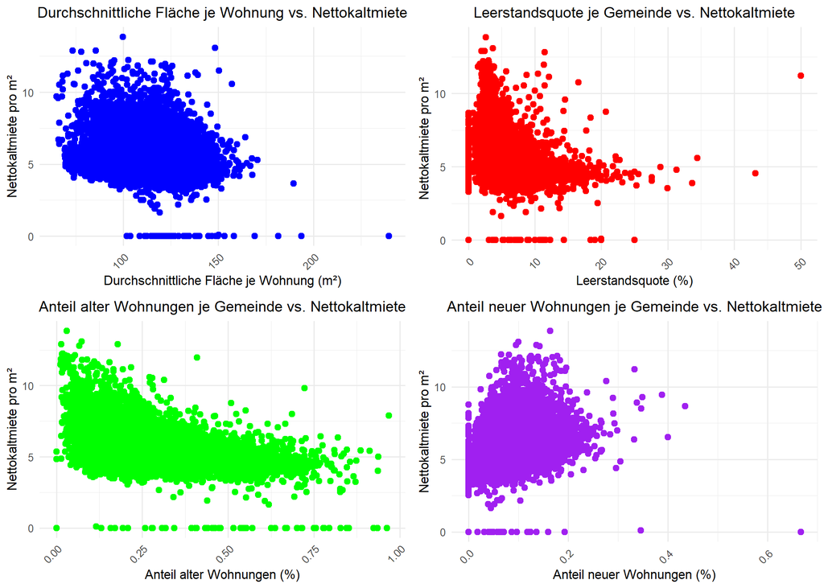

Eine inverse Beziehung lässt sich zwischen der Leerstandsquote und der Nettokaltmiete feststellen; mit steigender Leerstandsquote sinkt die Nettokaltmiete. Besonders hohe Leerstandsquoten gehen oft mit besonders niedrigen Mietpreisen einher.

Im Hinblick auf die Wohnfläche lässt sich keine signifikante lineare Korrelation mit dem Quadratmeterpreis erkennen. Die Datenverteilung zeigt sich relativ breit und chaotisch, besonders bei kleineren Wohnflächen. Dennoch besteht eine schwache Tendenz dahin, dass größere Wohnungen einen geringeren Mietpreis pro Quadratmeter haben.

Die Analyse der Leerstandsquote weist auf eine signifikant negative Korrelation hin. Höhere Leerstandsquoten sind mit niedrigeren Mietpreisen verbunden. In Gemeinden mit geringer Leerstandsquote gibt es für Wohnungssuchende weniger Auswahl, was die Preise aufgrund des knappen Angebots bei gleichzeitig hoher Nachfrage in die Höhe treibt.

Der Anteil alter Wohnungen wirkt sich ebenfalls auf die Mietpreise aus, wobei eine negative Korrelation festzustellen ist: In Gemeinden mit einem hohen Anteil alter Wohnungen sind die Mieten tendenziell niedriger. Dies könnte auf eine veraltete Ausstattung oder einen schlechteren Zustand der Wohnungen zurückzuführen sein.

Im Gegensatz dazu zeigt der Anteil neuer Wohnungen eine positive Korrelation: In Gebieten mit mehr Neubauten sind die Mietpreise meist höher, da diese Wohnungen moderner und attraktiver für Mieter sind.

In der vorherigen Aufgabe wurden Zusammenhänge zwischen dem Alter von Wohnungen und dem Mietpreis auf Gemeindeebene untersucht. Nun soll der Fokus darauf liegen, wie sich die Wohnungen in größeren Städten hinsichtlich ihres Alters verteilen.

8. Erstellen Sie ein Balkendiagramm für alle nachfolgenden Städte: `Stuttgart, Landeshauptstadt`, `Ulm, Universitätsstadt`, `Düsseldorf, Stadt`, `Berlin, Stadt`. Betrachten Sie dabei, wie das Alter der Wohnungen zwischen den Städten variiert. Sie sollen analysieren, wie groß der Anteil der Wohnungen abhängig nach den jeweiligen Baujahrsgruppen in den Städten ist. Tragen Sie in ihrem Balkendiagramm den *Anteil der Wohnungen nach den Baujahren* (auf der y-Achse) gegeben der *Baujahre für jede Stadt* (auf der x-Achse) ab.

Beschreiben und interpretieren Sie die Grafik. Haben Sie diese Unterschiede erwartet? Begründen Sie warum oder warum nicht.

*Hinweis:* Denken Sie daran das Faktorvariablen in ggplot hilfreich sein können.

`

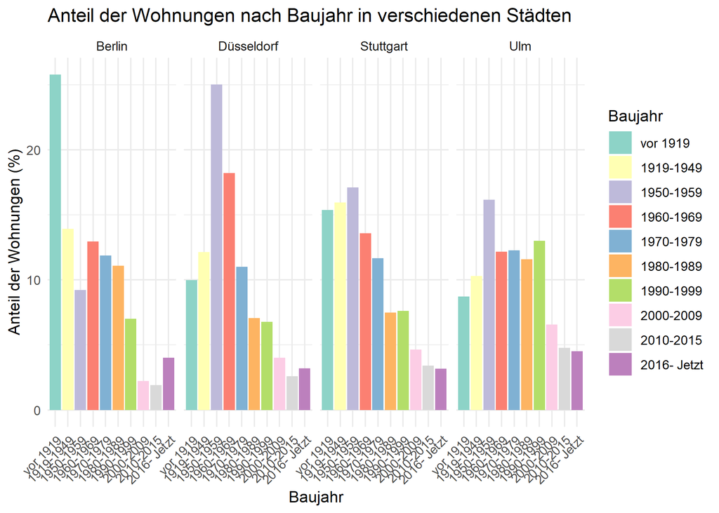

Quellen die bei der Interpretation hilfreich waren: https://www.destatis.de/DE/Presse/Pressemitteilungen/2023/06/PD23_N041_31.html#:~:text=Den%20bisher%20h%C3%B6chsten%20Stand%20erreichte,neuen%20Wohnungen%20im%20gesamtdeutschen%20Bundesgebiet. Aufgerufen am 02.12.2024

https://www.historisches-lexikon-bayerns.de/Lexikon/Wohnungspolitik_(Weimarer_Republik) Aufgerufen am 02.12.2024

9. Wie in der vorherigen Aufgabe zu sehen war, unterscheidet sich die Situation in Städten in Bezug auf die jeweiligen Baujahre der Wohnungen deutlich. Es wäre noch spannend zu sehen, ob auch das Alter der Bewohner, die Familienstände, oder die Einwanderungshistorie der Bewohner mit unterschiedlichen Mietpreisen assoziiert sind. Hier sollen Sie in einem ersten generellen Schritt ein paar demografische Faktoren einbeziehen, inwiefern diese eine Auswirkung haben. Betrachten Sie folgende Eigenschaften genauer:
- Familienstand
- Alter der Bewohner
- Einwanderungsgeschichte

Erstellen Sie eine oder mehrere passende Diagramme oder Grafiken für die in Aufgabe 8 aufgeführten Städte.

Beschreiben und interpretieren Sie diese. Haben Sie diese Unterschiede erwartet? Begründen Sie warum oder warum nicht. Wo gibt es Ihrer Ansicht nach besondere Auffälligkeiten? Warum kann es bei der unterschiedlichen Einteilung der Altersgruppen zu Problemen kommen? Was wären Möglichkeiten, um etwaige Probleme zu vermeiden?

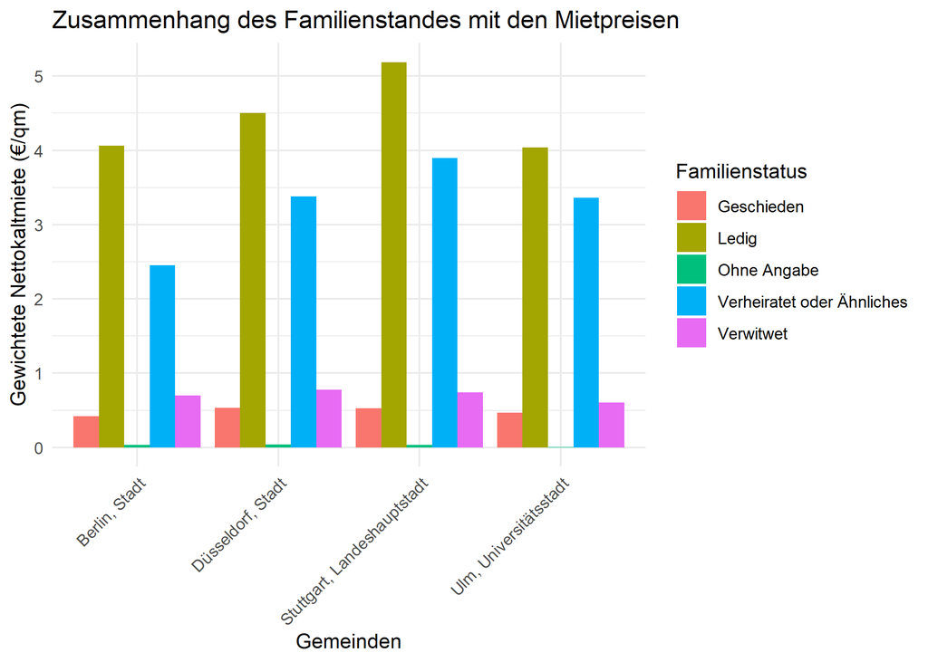

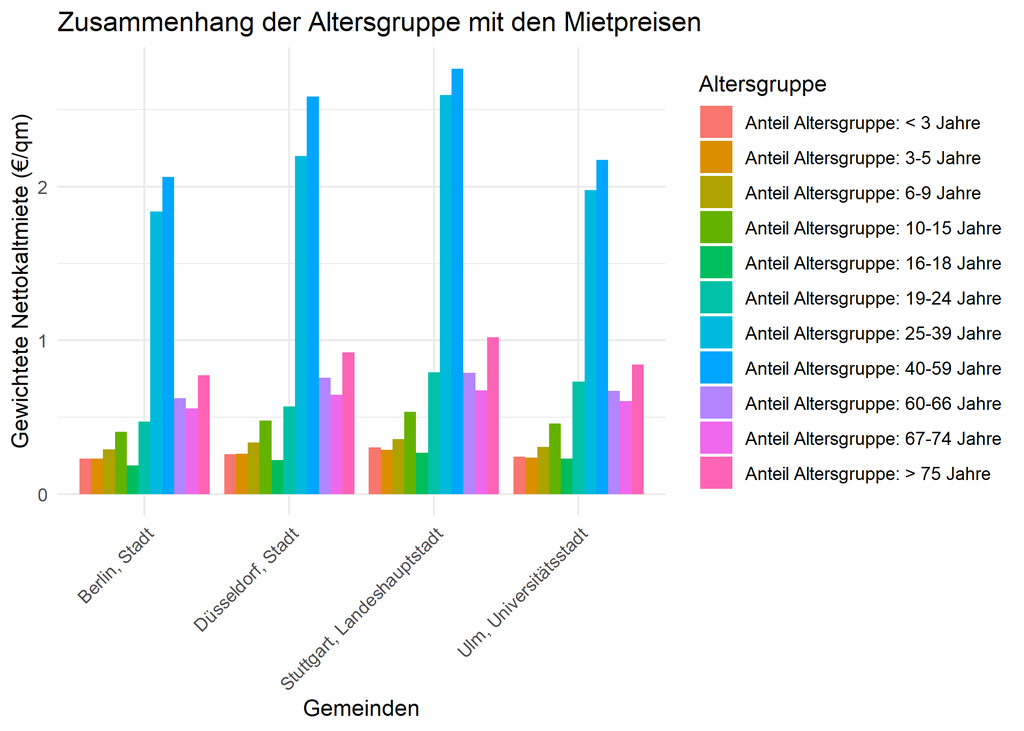

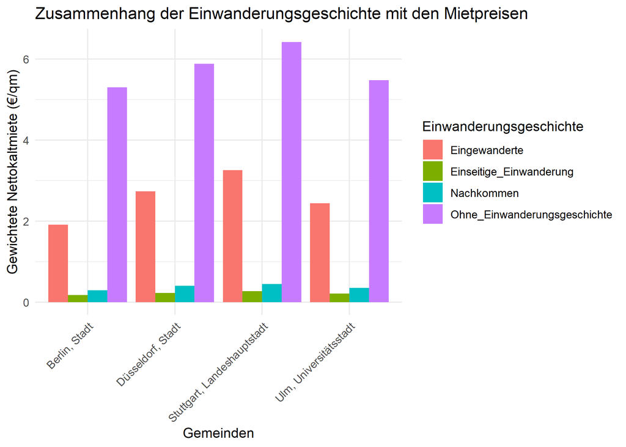

Grafik 1 Zusammenhang des Familienstandes mit den Mietpreisen. Diese Grafik zeigt wie der durchschnittliche Mietpreis pro Quadratmeter in verschiedenen Gemeinden auf verschiedene Familienstandsgruppen verteilt ist. Auffällig hier ist das ledige Menschen und verheiratete Menschen oft in den teuersten Wohnungen, gewichtet an Nettokaltmiete €(qm), leben. Bei verheirateten Paaren oder Menschen die mit Ihrer oder Ihrem Lebengefährten zusammen in der gleichen Wohnung leben, können sich meist teurere Wohnungen leisten, da meist zwei Einkommen vorhanden sind. Das so viele ledige Menschen in teuren Wohnungen gemessen an Nettokaltmiete €(qm) leben kann verschiedene Gründe haben. Ledige Personen sind oft in der Anfangs- oder Mitte ihrer Karriere und ziehen berufsbedingt in Städte mit höheren Lebenshaltungskosten, wo sich viele Arbeitsmöglichkeiten in gut bezahlten Branchen befinden. Solche Städte tendieren dazu, höhere Mieten zu haben. Zudem sind viele ledige Personen Studierende oder junge Berufstätige, die in der Nähe von Universitäten oder Ausbildungsstätten wohnen möchten, die sich oft in städtischen Gebieten mit höheren Mietpreisen befinden.

Grafik 2 Zusammenhang der Altersgruppe mit den Mietpreisen. Auffällig hier sind vorallem die extremen Ausreißer in den Altersgruppen zwischen 25-39 und 40-59. Bei unterschiedlicher Einteilung der Altersgruppen kann es zu vielen Problemen kommen. Altersgruppen, die sehr unterschiedlich groß sind, können zu Verzerrungen in der Darstellung führen. Kleinere Altersgruppen könnten übermäßig oder unterrepräsentiert erscheinen, da ihre Pro-Kopf-Miete hoch oder niedrig erscheint, schlichtweg aufgrund der geringeren Anzahl an Mitgliedern und nicht aufgrund tatsächlich hoher Wohnausgaben. Unterschiede im Mietverhalten zwischen jüngeren und älteren Generationen (z.B. jüngere Generationen, die flexibler sind und bereit sind, mehr für kürzere Mietverhältnisse auszugeben) könnten hier verloren gehen. Zudem hätte man die ersten vier bis Fünf Balken auch zusammen nehmen können, da die meisten Menschen in diesem Alter noch zuhause bei Ihren Eltern oder Erziehungsberechtigten wohnen. Es wäre möglich zusätzlich zu den allgemeinen Gruppen auch spezifische Untergruppen zu untersuchen, wenn ausreichend Daten vorhanden sind, um bedeutungsvolle Schlussfolgerungen zu ziehen. Desweitern könnte man Probleme vermeiden indem man sicherstellt, dass die Altersgruppen hinsichtlich Lebensstil und Wohnpräferenzen so homogen wie möglich sind.

Grafik 3 Zusammenhang der Einwanderungsgeschichte mit den Mietpreisen. Wir sehen das Menschen mit Migrationshintergrund meist in billigeren Wohnungen leben als Menschen ohne Migrationshintergrund. Das kann verschiede Hintergründe haben. Zum einen haben Personen mit Migrationshintergrund in einigen Fällen ein geringeres Einkommen. Dies kann aus unterschiedlichen Gründen der Fall sein, wie z.B. Diskriminierung auf dem Arbeitsmarkt, Qualifikationsanerkennungen oder sprachliche Barrieren, die den Zugang zu gut bezahlten Jobs erschweren. Ein geringeres Einkommen schränkt die Wahlmöglichkeiten für den Wohnort ein. Zudem müssen neu angekommene Migranten oft schnell und kurzfristig eine Unterkunft finden, was sie dazu veranlassen kann, in günstigeren, oft auch in schlechteren Wohngegenden zu wohnen, in denen Wohnungen schneller verfügbar und oft auch weniger reguliert sind. Desweitern gibt es Fälle, in denen Menschen mit Migrationshintergrund auf dem Wohnungsmarkt diskriminiert werden. Dies kann bedeuten, dass sie trotz gleicher finanzieller Möglichkeiten häufiger für teurere oder schlechtere Wohnungen ausgewählt werden oder es schwieriger finden, in bestimmten Top-Lagen Wohnungen zu bekommen. Es gibt eine vielzahl an Möglichkeiten um hier entgegen zu wirken. Programme zur Anerkennung ausländischer Qualifikationen und Abschlüsse beschleunigen, um den Zugang zu qualifizierteren und besser bezahlten Jobs zu ermöglichen. Sprachkurse und Fortbildungsprogramme anbieten, um Chancen auf dem Arbeitsmarkt zu verbessern. Striktere Durchsetzung von Gesetzen gegen Diskriminierung auf dem Wohnungsmarkt, um Chancengleichheit bei der Wohnungssuche zu gewährleisten. Sensibilisierungskampagnen und Schulungen für Vermieter und Makler, um Vorurteile und Diskriminierung abzubauen. ——

In den bisherigen Analysen wurden demografische und wohnungsbezogene Faktoren in verschiedenen Städten Deutschlands untersucht. Dabei lag der Fokus darauf, wie diese Merkmale in unterschiedlichen Regionen das Mietpreisniveau und dessen Struktur beeinflussen. Aufbauend auf diesen Erkenntnissen soll der Blick nun gezielt auf den Vergleich zwischen Ost- und Westdeutschland gelenkt werden. Diese regionale Differenzierung ermöglicht es, potenzielle Unterschiede und Gemeinsamkeiten zwischen den beiden Landesteilen genauer zu analysieren. Insbesondere wird betrachtet, wie sich die Mietpreisstruktur in Ost- und Westdeutschland darstellt und ob sich hierbei spezifische Muster oder Abweichungen erkennen lassen.

10. Betrachten Sie nun die Städte `Dresden, Stadt`, `Chemnitz, Stadt`, `Stuttgart, Landeshauptstadt`, `Ulm, Universitätsstadt`,`Düsseldorf, Stadt`und `Berlin, Stadt`. Vergleichen Sie in einem ersten Schritt die Anzahl an Einwohnern, den Anteil an Menschen, die deutscher Herkunft sind, den Anteil an neuen und alten Wohnungen, sowie die durchschnittlichen Mietpreise. Erweitern Sie ihre Analyse um die durschnittlichen Wohnflächen.

Erstellen Sie für die genannten Städte eine deskriptive Tabelle. Beschreiben und interpretieren Sie diese. Beantworten Sie insbesondere folgende Fragen:

- In wie weit könnte das Alter der Wohnungen eine Rolle für den Mietpreis spielen?
- Gibt es Auffälligkeiten zwischen den einzelnen Städten in Bezug auf Herkunft der Bewohner, Einwohner und Größe der Wohnungen?
- Warum könnte es problematisch sein, wenn Sie die Städte als ein Ganzes betrachten?
- Sind Ihre Ergebnisse auf die ganze Stadt verallgemeinerbar?
- Was sind ihrer Meinung nach Faktoren, die die unterschiedlichen Mietpreise in Ost und West erklären?
- Welche Maßnahmen wären geeignet, um in Düsseldorf, Ulm und Stuttgart die Mietpreisstruktur anzupassen und bezahlbaren Wohnraum zu schaffen?
- In wie weit könnte das Alter der Wohnungen eine Rolle für den Mietpreis spielen?

- Gibt es Auffälligkeiten zwischen den einzelnen Städten in Bezug auf Herkunft der Bewohner, Einwohner und Größe der Wohnungen?

- Warum könnte es problematisch sein, wenn Sie die Städte als ein Ganzes betrachten?

Es könnte problematisch sein, die Städte als ein Ganzes zu betrachten, weil jede Stadt aus verschiedenen Stadtteilen oder Gemeinden besteht, die sich in Bezug auf soziale, wirtschaftliche und infrastrukturelle Faktoren stark unterscheiden können. Diese Unterschiede können die Mietpreise, die demografische Struktur oder die Wohnverhältnisse beeinflussen. Wenn man die gesamte Stadt ohne Berücksichtigung dieser Unterschiede betrachtet, könnte man wichtige Details übersehen und verzerrte Schlussfolgerungen ziehen.

- Sind Ihre Ergebnisse auf die ganze Stadt verallgemeinerbar?

Innerhalb einer Stadt gibt es oft starke Unterschiede zwischen verschiedenen Vierteln in Bezug auf Bevölkerungsdichte, sozioökonomischen Status und Lebensqualität. So könnten einige Stadtteile sehr wohlhabend und andere einkommensschwächer sein. Ein Durchschnitt über die ganze Stadt kann diese Unterschiede verwässern und keine akkurate Darstellung der Wohnsituation in den spezifischen Gebieten liefern. Unterschiedliche Stadtteile könnten unterschiedlich stark von Neubauten betroffen sein oder unterschiedliche Infrastrukturen besitzen, was lokal zu variierenden Wohnbedingungen und Mietpreisen führen kann. Die Zusammensetzung der Bevölkerung hinsichtlich Alter, Herkunft und Lebensweise kann je nach Stadtteil stark variieren. Dadurch kann der Einfluss dieser Faktoren auf die Wohnsituation innerhalb der Stadt unterschiedlich sein. Die präsentierten Daten spiegeln Stadtgesamtwerte wieder und könnten nicht auf die individuellen Viertel oder spezifischen demografischen Gruppen innerhalb der Stadt anwendbar sein. Vor allem, weil: - Es große Abweichungen innerhalb verschiedener Stadtteile geben kann. - Bestimmte Branchen oder Universitäten in einzelnen Stadtteilen dominieren könnten, was die Wohnnachfrage in diesen Gebieten beeinflusst. - Politik, lokale Initiativen und historische Entwicklungen, die spezifische Viertel betreffen, den gesamten Mietpreis der Stadt nicht umfassend widerspiegeln können.

- Was sind ihrer Meinung nach Faktoren, die die unterschiedlichen Mietpreise in Ost und West erklären?

Historische Unterschiede: Ost- und Westdeutschland hatten unterschiedliche politische, soziale und wirtschaftliche Entwicklungen, die auch Jahrzehnte nach der Wiedervereinigung noch Einfluss auf den Immobilienmarkt haben. Wirtschaftliche Disparitäten: Im Westen gibt es oft mehr wirtschaftliche Aktivität und höhere Einkommen, was zu einem stärkeren Druck auf den Wohnungsmarkt führt. Daher sind die Mieten im Allgemeinen höher. Infrastrukturentwicklung: Die Infrastruktur im Westen war historisch besser entwickelt, was Städte attraktiver machte. Dies führt zu einer größeren Nachfrage nach Wohnraum. Bevölkerungswachstum und Urbanisierung: In vielen westlichen Städten ist das Bevölkerungswachstum höher, was zu höherer Nachfrage nach Wohnraum führt. Engere Vernetzung und Anbindung: Bessere Verkehrsanbindungen und engere Anbindungen an internationale Netzwerke machen westliche Städte attraktiv für Unternehmen und Individuen, was den Wohnungsmarkt stärker belastet.

- Welche Maßnahmen wären geeignet, um in Düsseldorf, Ulm und Stuttgart die Mietpreisstruktur anzupassen und bezahlbaren Wohnraum zu schaffen?

Förderung des sozialen Wohnungsbaus: Steigerung des Angebots an bezahlbaren Wohnungen durch staatlich geförderte Wohnbauprogramme. Nachverdichtung urbaner Räume: Effiziente Nutzung bereits vorhandener städtischer Flächen durch den Bau von Mehrfamilienhäusern oder Umnutzung von leerstehenden Gewerbeimmobilien. Subventionen für energieeffiziente Renovierung: Unterstützung für Vermieter bei der Renovierung alter Gebäude zur Senkung der Betriebskosten, was langfristig zu niedrigeren Mieten führen könnte. Regulierung von Mietpreisen: Einführung von Mietpreisbremsen oder Obergrenzen, um überhöhte Mieten in beliebten Stadtteilen zu verhindern. Förderung von kooperativen und gemeinschaftlichen Wohnformen: Unterstützung von Wohnprojekten, die gemeinschaftlich betrieben werden und kostengünstiger sein können als traditionelle Mietwohnungen. Verbesserung der Verkehrsanbindung: Ausbau des öffentlichen Verkehrs zur Entlastung zentraler Stadtbereiche und zur Erschließung von neuen, günstigeren städtischen oder stadtnahen Regionen.

Diese Maßnahmen können dazu beitragen, den Druck auf den Mietmarkt zu reduzieren und den Zugang zu bezahlbarem Wohnraum zu verbessern.

11. Lesen Sie den [folgenden Artikel](https://www.tagesschau.de/wirtschaft/sozialwohnungen-bau-mangel-101.html). Dort werden Sozialwohnungen thematisiert, warum so viele fehlen und wer davon vor allem betroffen ist. Beantworten Sie anschließend folgende Fragen:
- Welche Bevölkerungsgruppen sind am stärksten von der Sozialwohnungsnot betroffen und inwiefern?
- Was sind Gründe, warum es zu wenige Sozialwohnungen gibt?
- Wie sieht die historische Entwicklung des Sozialwohnungsbaus aus, im Hinblick auf Vorhandensein von Wohnungen und Investitionen in den Bau von neuen Wohnungen?
- Welche Anreize könnten Investoren motivieren, mehr Sozialwohnungen zu bauen?
- Welche innovativen Ansätze können Bauherren verfolgen, um die Kosten für den Wohnungsbau zu senken?

Besonders arme Familien, die in finanzielle Not geraten sind, sowie Menschen mit geringem Einkommen sind stark betroffen, da sie oft keine bezahlbaren Wohnungen finden können.

Gründe für den Mangel: Wohnungen fallen nach einer festgelegten Zeit aus der Sozialbindung und werden Teil des freien Marktes, die Preise für Materialien und Arbeitskräfte sind stark gestiegen, was den Bau verteuert, die staatliche Förderung für Sozialwohnungen wurde in der Vergangenheit stark reduziert.

Der Bestand an Sozialwohnungen ist von 3 Millionen in den 1990er Jahren auf 1,1 Millionen gesunken. Währenddessen wächst die Nachfrage, da die Mietpreise steigen und die Bevölkerung in Städten zunimmt.

Um Investoren zum Bau von Sozialwohnungen zu motivieren, könnten folgende Maßnahmen helfen: Zuschüsse und zinsgünstige Darlehen, reduzierte Mehrwertsteuer oder steuerliche Abschreibungen, Beschleunigung der Genehmigungsverfahren und Abbau unnötiger Hürden, die Bereitstellung von städtischen Flächen für den sozialen Wohnungsbau.

Der Artikel beschreibt, dass Bauherren Kosten senken können, indem sie modulare Bauteile einsetzen, die Bauzeit verkürzen und günstiger sind. Nachhaltige Materialien wie Holz oder recycelte Stoffe spielen ebenfalls eine Rolle. Die effektivere Nutzung vorhandener Flächen, etwa durch Aufstockungen oder Umwidmungen, ist ein weiterer Ansatz. Standardisierte Baupläne vereinfachen und beschleunigen Bauprozesse. Zudem könnten Partnerschaften zwischen öffentlichen und privaten Akteuren die Finanzierung und Umsetzung von Projekten fördern.

12. Gerade die Politik ist gefordert, bezahlbaren Wohnraum zu realisieren. Dabei gibt es eine Viezahl an politischen Maßnahmen, die aufgestellt wurden und umfangreich diskutiert werden. Betrachten Sie die folgenden Maßnahmen, welche helfen sollen, die angespannte Lage auf dem Mietmarkt zu entlasten. Argumentieren Sie, warum diese Maßnahmen sinnvoll/nicht sinnvoll sind und in welcher Art und Weise diese umgesetzt werden können.
1. “Fachleute fordern, die Regulierung von Bestandsmieten zu lockern, damit sich ihr Niveau den Neuvertragsmieten annähert, mehr Menschen umziehen und sich Wohnraum besser verteilt.”
2. “Eine weitere Möglichkeit wäre, Mieterhöhungen bei Neuvertragsmieten zu begrenzen.”
3. “Am einfachsten ist es, wenn vor allem in Großstädten, wo bezahlbarer Wohnraum fehlt, mehr gebaut wird.”
4. “Am besten wäre es, wenn zukünftig mehr Vermieter in regelmäßigen Abständen die Miete anpassen.”
1. Diese Idee könnte sinnvoll sein, da sie Wohnraum effizienter nutzbar machen könnte, wenn Menschen in kleinere oder passendere Wohnungen ziehen. Jedoch besteht die Gefahr, dass sozial schwächere Mieter durch höhere Kosten belastet werden. Damit dies tragbar wäre, müssten soziale Maßnahmen wie eine Erhöhung des Wohngeldes eingeführt werden.
2. Eine Begrenzung könnte den Mietmarkt stabilisieren und verhindern, dass Mieter durch hohe Anfangsmieten belastet werden. Allerdings wäre eine strenge Kontrolle notwendig, um sicherzustellen, dass Vermieter die Regeln einhalten.
3. Der Neubau, besonders in Großstädten, ist eine zentrale Lösung gegen Wohnraumknappheit. Um das umzusetzen, könnten Städte Genehmigungsverfahren beschleunigen und durch Förderprogramme Investitionen in den sozialen Wohnungsbau anregen.
4. Diese Maßnahme erscheint kritisch, da sie soziale Spannungen verstärken könnte. Wenn überhaupt, müsste sie klar reguliert werden, zum Beispiel durch eine Orientierung an der Inflationsrate, um eine Überforderung der Mieter zu vermeiden.

# Einzelne Stadtteile in Deutschland

In allen vorherigen Aufgaben haben Sie die Städte, Gemeinden oder auch Landkreise immer als ein Ganzes betrachtet. Jedoch ist es schwierig gerade in Großstädten wie Berlin, Düsseldorf oder auch Stuttgart allgemeine Aussagen über die Mietsituation auf Stadtebene zu treffen. Dies liegt unter anderem daran, dass unterschiedliche Stadtviertel unterschiedliche demografische Eigenschaften, sowie eine unterschiedliche Mietstruktur aufweisen können. Hier wäre es sinnvoll sich mit dem Stadtbild und der Verteilung der Mieten genauer auseinanderzusetzen, um zu sehen, wie sich Mieten innerhalb der Stadt verteilen. Wie in Aufgabe 10 zu sehen war, weisen die Städte im Westen Deutschlands untereinander, sowie die Städte im Osten ähnliche Merkmale auf, weshalb Sie sich in den folgenden Aufgaben auf je eine große und eine kleinere Stadt aus beiden Regionen konzentrieren.

13. In dieser Aufgabe sollen Sie ihren Datensatz aus Aufgabe 4, bei dem Sie Kartendaten und Informationen zu Mieten und LEQ auf 1km-Gitterebene heruntergeladen und zusammengefügt haben, verwenden und vier Karten zeichnen, welche die Verteilung der Nettokaltmieten in den Stadtteilen der Städte “Stuttgart, Landeshauptstadt”, “Ulm, Universitätsstadt”, “Chemnitz, Stadt” und “Dresden, Stadt” anschaulich visualisieren.

Erstellen Sie vier Grafiken, beschreiben und interpretieren diese. Gehen Sie insbesondere auf folgende Fragen ein:

- Welche Besonderheiten fallen Ihnen bei diesen Städten auf?
- Gibt es eine Segregation in Bezug auf die Mieten in einzelnen Stadtteilen?
- Falls es eine Segregation gibt, welche Konsequenzen könnte dies haben?
- Welche Rolle spielen geografische oder infrastrukturelle Faktoren bei den Mietpreisen?
- Gibt es Unterschiede zwischen Städten im Osten und Westen Deutschlands, falls ja, welche Einflüsse in Bezug auf Wirtschaft und Arbeitsmarkt könnte dies in den jeweiligen Städten haben?

*Hinweis:* Wenn Sie einheitliche Legenden für die Karten haben möchten und die vier Städte nebeneinander oder untereinander darstellen wollen, so empfiehlt sich das Paket `ggpubr` und dort der Befehl `ggarrange`.

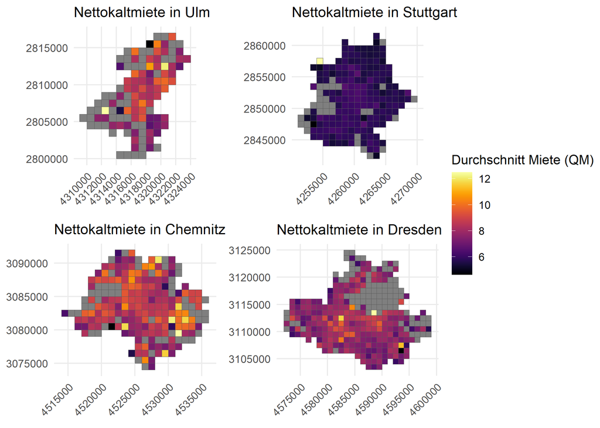

14. Nachdem Sie in Aufgabe 13 die Verteilung der Mieten der einzelnen Stadtteile visualisiert haben, sollten Sie in dieser Aufgabe den Anteil der Leerstandsquoten in den Stadtteilen der Städte “Stuttgart, Landeshauptstadt”, “Ulm, Universitätsstadt”, “Chemnitz, Stadt” und “Dresden, Stadt” veranschaulichen.

Erstellen Sie vier Grafiken, beschreiben und interpretieren diese. Gehen Sie insbesondere auf folgende Fragen ein:

- Was könnten Gründe sein, dass die Leerstandsquote in bestimmten Stadtteilen höher ist, als in anderen?
- Welche Besonderheiten fallen Ihnen bei diesen Städten auf? Auch im Hinblick auf ihre Erkenntnisse aus Aufgabe 13.
- Vergleichen Sie die Grafiken aus Aufgabe 13 und Aufgabe 14. Was könnte der Grund für die unterschiedlichen Muster sein?
- Welche Maßnahmen ergreifen Städte mit hohen Leerstandsquoten, um diese zu reduzieren?

*Hinweis:* Wenn Sie einheitliche Legenden für die Karten haben möchten und die vier Städte nebeneinander oder untereinander darstellen möchten, so empfiehlt sich das Paket `ggpubr` und dort der Befehl `ggarrange`.

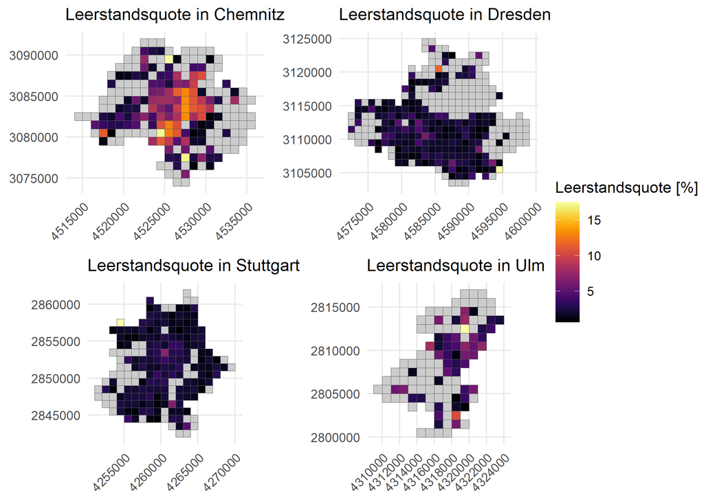

In Stadtteilen mit höheren Leerstandsquoten spielen oft wirtschaftlich ungünstigere Bedingungen eine Rolle. Dazu gehören zum Beispiel weniger Arbeitsplätze, eine schlechte Anbindung an den öffentlichen Nahverkehr oder eine schwächere Infrastruktur. Diese Faktoren machen die Gegend für potenzielle Mieter weniger attraktiv, was zu mehr Leerstand führt. Besonders in Randgebieten oder weniger zentralen Stadtteilen, die schlecht an öffentliche Verkehrsmittel oder Wirtschaftszentren angeschlossen sind, ist die Leerstandsquote oft höher. Dagegen sind zentrale, gut erschlossene Gebiete in der Regel stärker gefragt.

In Stuttgart ist der Leerstand in den zentralen Stadtteilen relativ niedrig, was an der hohen Nachfrage nach Wohnraum in der Innenstadt liegt. In Ulm sind die Leerstandsquoten insgesamt ebenfalls eher gering. Als Universitätsstadt hat die Stadt eine konstante Nachfrage nach Wohnungen, sowohl von Studierenden als auch von Pendlern. Im Vergleich zu anderen Städten wie Chemnitz sind die Leerstandsquoten in Ulm moderat, was auf die hohe Attraktivität und stabile Mietpreise hinweist.

Dresden zeigt ähnliche Muster wie Chemnitz, allerdings mit weniger extremen Leerstandsquoten. Die zentrale Lage und das touristische Potenzial sorgen dafür, dass der Leerstand in der Innenstadt gering bleibt, während in den Randgebieten, die weniger attraktiv sind, die Leerstandsquoten höher ausfallen.

Städte könnten den Neubau von Wohnungen, insbesondere in den Randgebieten, anregen, um den steigenden Wohnraumbedarf zu decken und die Leerstandsquote zu senken. In Bereichen mit besonders hohen Leerständen könnte zudem der soziale Wohnungsbau gefördert werden, um die Mietpreise zu stabilisieren und gleichzeitig bezahlbaren Wohnraum für Menschen mit geringeren Einkommen zu schaffen. Darüber hinaus könnte eine bessere Anbindung dieser Randgebiete an zentrale Wirtschafts- und Arbeitszentren helfen, die Nachfrage nach Wohnungen zu steigern und so die Leerstände zu verringern.

15. Die aktuellen Mietpreise und deren Entwicklungen hindern in Deutschland immer mehr Menschen daran, dass sie sich eine neue geeignete Wohnung suchen. Personen, die aufgrund ihrer aktuellen Lebenssituation sich nach einer neuen Wohnung umsehen, finden oft keine oder können sich diese nicht leisten. Doch worin liegen die Ursachen und Probleme?

Beantworten Sie hierzu folgende Fragen:

- Was versteht man unter dem Lock-in-Effekt, speziell in Bezug auf den Mietmarkt? Wer ist davon vor allem betroffen und warum?
- Gibt es aktuell Möglichkeiten, die vor allem diese “betroffenen” Personen haben, um an bezahlbaren Wohnraum zu gelangen?
- Worin liegen die Ursachen, dass Bestandsmieten (Mieten aus bestehenden Verträgen) und Angebotsmieten (Mieten aus Neuverträgen) so stark voneinander abweichen?

Gehen Sie in ihrer Argumentation auch auf die Grafiken und Ergebnisse der Aufgaben 11, 13 und 14 ein.

Der Lock-in-Effekt im Mietmarkt beschreibt eine Situation, in der Mieter in ihrer aktuellen Wohnung bleiben, obwohl sie sich möglicherweise eine andere, passendere Unterkunft wünschen oder benötigen würden. Dies geschieht hauptsächlich, weil die Differenz zwischen der Miete der bestehenden Wohnung und den deutlich höheren Mieten auf dem aktuellen Wohnungsmarkt so groß ist, dass ein Umzug finanziell unattraktiv oder unmöglich wird. Vom Lock-in-Effekt betroffen sind, wie bei Aufgabe 11 aufgezählt, vor allem langjährige Mieter, die von vergleichsweise günstigen Bestandsmieten profitieren, sowie Familien, ältere Menschen und Geringverdiener. Ebenso trifft er Personen, deren Lebensumstände sich verändert haben, etwa durch Familienzuwachs, eine Trennung oder einen Arbeitsplatzwechsel.

Betroffene Personen haben mehrere Möglichkeiten, an bezahlbaren Wohnraum zu gelangen, obwohl diese oft begrenzt sind. Eine Option ist der Zugang zu Sozialwohnungen, jedoch gibt es einen Mangel an solchen Wohnungen. Weitere Unterstützung bieten staatliche Leistungen wie Wohngeld, um hohe Mietkosten zu decken. Manche ziehen in weniger nachgefragte Regionen um, um günstigere Mieten zu finden, was jedoch mit Nachteilen wie längeren Arbeitswegen verbunden ist. Das sieht man auch in Aufgabe 13 und 14, dass in den Ballungsgebiten die Miete höher ist und die Leerstandsquote geringer ist.

Die starke Abweichung zwischen Bestandsmieten und Angebotsmieten lässt sich durch verschiedene Faktoren erklären. Erstens sind Bestandsmieten oft durch gesetzliche Regelungen wie die Mietpreisbremse oder Mietobergrenzen begrenzt, was bedeutet, dass Mieten in bestehenden Verträgen nur begrenzt steigen dürfen. Diese Regelungen gelten für viele Mietverhältnisse und halten die Mieten auf einem niedrigeren Niveau. Im Gegensatz dazu sind Angebotsmieten, die bei Neuvermietungen anfallen, nicht durch solche Begrenzungen beeinflusst. Sie spiegeln den aktuellen Zustand des Marktes wider, der von einer hohen Nachfrage und einem begrenzten Angebot an verfügbaren Wohnungen geprägt ist. Besonders in großen Städten und Ballungsräumen sind die Angebotsmieten daher häufig deutlich höher, da Vermieter die Marktlage ausnutzen können, um höhere Mieten zu verlangen. Zusätzlich spielt die Inflation eine Rolle, da steigende Baukosten und höhere Betriebskosten oft zu einer Erhöhung der Angebotsmieten führen. Die Daten der Aufgabe 14 unterstreichen, dass vor allem Neubauten und hochpreisige Mietobjekte betroffen sind, was zusätzlich die Differenz zwischen Bestands- und Angebotsmieten verstärkt.

Quellen die bei der interpretation nützlich waren: https://hub.hslu.ch/immobilienblog/2023/12/05/die-folgen-der-mietmarktregulierung-lock-in-effekt-ineffiziente-nutzung-von-wohnraum-und-planungsunsicherheit-fuer-neue-wohnungen/ aufgerufen am 06.12.2024

https://www.timourou.de/mieten-sind-nicht-gleich-mieten/ aufgerufen am 06.12.2024

# Stadt vs. Land

Bisher haben Sie sich intensiv mit der Wohnsituation in Deutschland auseinandergesetzt und dabei insbesondere die Unterschiede zwischen Ost- und Westdeutschland betrachtet. Im Fokus standen dabei die Mietpreisentwicklung und die Rolle verschiedener Faktoren wie demografische Merkmale, Leerstandsquote, Eigentümerquote, sowie die Wohnfläche. Diese Analysen haben wertvolle Erkenntnisse über die regionale Dynamik des Mietmarkts geliefert.

Nun sollen Sie ihren Blickwinkel erweitern und den Fokus auf eine weitere Ebene der Analyse richten. Im Kern sollen Sie den Unterschied zwischen städtischen Regionen, insbesondere Großstädten, und ländlichen Gebieten untersuchen. Hierbei soll die Mietstruktur in diesen beiden Raumtypen analysiert werden, ob sich die Strukturen von Stadt und Land voneinander unterscheiden.

16. Betrachten Sie in einem ersten Schritt die Wohnungen abhängig ihres Alters. Erstellen Sie dazu eine passende Grafik, die die Verteilung der Wohnungen nach Altersgruppen für die Stadt `Stuttgart, Landeshauptstadt` (Landkreis: Stuttgart, Stadtkreis) im Vergleich zum `Alb-Donau-Kreis` und `Ostalbkreis` darlegt.

Beschreiben und interpretieren Sie ihre Grafik. Woran könnte es liegen, dass es in Stuttgart (in der Stadt) deutlich mehr Altbauwohnungen als auf dem Land gibt? Könnten politische Maßnahmen ihrer Ansicht nach helfen, dass auch in Großstädten mehr neue Wohnungen erbaut und zur Vermietung zur Verfügung gestellt werden?

*Hinweis 1:* Nutzen Sie für die Visualisierung einen Mosaik- oder ein “stacked” Balkendiagramm. Eine Idee, wie Sie das Ganze darstellen können, finden Sie [hier](https://r-graph-gallery.com/).

*Hinweis 2:* Für Stuttgart soll der komplette Landkreis (“Stadtkreis”) untersucht werden.

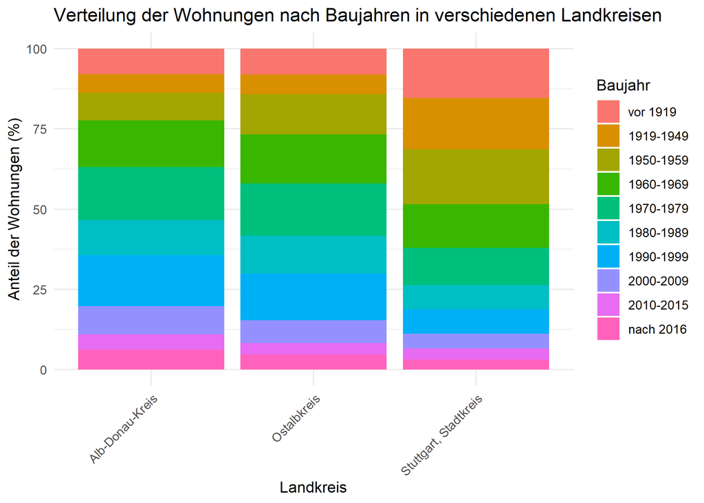

Wir sehen in der GRafik das vorallem in Stuttgart der Anteil an Altbauwohnungen im Vergleich zum Alb-Donau-Kreis und Ostalbkreis sehr hoch ist. Dies hat verschiedene Gründe. Zum einen haben Städte wie Stuttgart eine lange Geschichte und viele ihrer Wohngebiete wurden in früheren Jahrhunderten, besonders im 19. und frühen 20. Jahrhundert, entwickelt. Diese Altbauten sind oft ein integraler Teil des städtischen Charakters und der Kultur. Desweiteren ist In dicht besiedelten Stadtgebieten der Platz für Neubauten oft begrenzt, was Investitionen in die Renovierung bestehender Gebäude begünstigt. Zudem sind Bauland in Innenstädten kostspielig und schwer verfügbar. Altbauten tragen sehr oft zur ästhetischen und historischen Attraktivität einer Stadt bei und werden daher oft erhalten.

Ja politische Maßnahmen könnten helfen, dass auch in Großstädten mehr neue Wohnungen erbaut und zur Vermietung zur Verfügung gestellt werden. Die Politik könnte beispielsweise verschiede Anreize oder Förderprogramme augf den Weg bringen. Dies könnte durch Subventionen, steuerliche Anreize oder günstige Kredite für Entwickler, die nachhaltige und effiziente Projekte in Stadtgebieten entwickeln, geschehen. Wie wir aus vorangegangen analysen gelernt haben scheitert neuer Wohnungsbau sehr oft an der komplexen Bürokratie. Eine Möglichkeit Wohnungsbau zu fördern wäre es Bürokratie abzubauen und Anpassungen der Bauvorschriften, um Bauprozesse zu beschleunigen. Das könnte das vereinfachen von Genehmigungsverfahren und das Abbau von bürokratischen Hürden beinhalten. Die Erlaubnis von Aufstockungen bei bestehenden Gebäuden kann Wohnraumbeschränkungen in dicht bebauten Gebieten abmildern.

Maßnahmen wie diese könnten helfen, den Wohnraumbedarf in Städten wie Stuttgart zu decken und gleichzeitig den charakteristischen Charme und das historische Erbe der Stadt zu bewahren. Dabei ist es wichtig darauf zu achten, dass Neubauten nicht zu Gentrifizierung führen, sondern vielmehr bezahlbaren Wohnraum sicherstellen.

In einem weiteren Schritt sollen Sie nun die Mietpreise und deren Verteilung analysieren. Hierbei sollen Sie neben der Leerstands- und Eigentümerquote auch auf die Verteilung der Wohnungen nach deren Wohnfläche achten und diese untersuchen.

17 (a). Erstellen Sie zuerst eine Tabelle, die die durchschnittlichen Mietpreise mit der Leerstands- und Eigentümerquote darstellt. Was fällt ihnen dabei besonders auf? Beschreiben und interpretieren Sie ihre Tabelle.

17 (b). Erstellen Sie eine weitere Grafik, die die Verteilung der Wohnungen nach den einzelnen Wohnungsgrößen(<40m² bis >=200m²) abbildet. Stellen Sie darüber hinaus den durchschnittlichen Mietpreis je Landkreis in einer weiteren Grafik dar. Beschreiben und interpretieren Sie ihre Grafiken. Gehen Sie insbesondere auf die Frage ein, ob es Sinn macht sich vor allem den Ostalbkreis oder Alb-Donau-Kreis als ein Ganzes anzusehen und inwieweit überhaupt ein Vergleich zwischen Stadt und ländlicher Region möglich ist.

*Hinweis:* Hier sollen Sie erneut auf dieselben Städte und Landkreise aus Aufgabe 16 eingehen!

| Landkreis | Durchschnittlicher Mietpreis | Leerstandsquote | Eigentümerquote |
| --- | --- | --- | --- |
| Alb-Donau-Kreis | 6.37 | 5.34 | 71.44 |
| Ostalbkreis | 6.27 | 5.09 | 70.59 |
| Stuttgart, Stadtkreis | 10.39 | 3.46 | 31.15 |

Es fällt besonders auf, dass die Mietpreise wesentlich höher sind in Stuttgart als in den ländlicheren Gebieten Alb-Donau-Kreis und Ostalbkreis. In städtischen Zentren wie Stuttgart, ist die Nachfrage nach Wohnraum aufgrund der höheren Bevölkerungsdichte, besseren Infrastruktur und Arbeitsmöglichkeiten höher.In ländlicheren Regionen, wie dem Alb-Donau-Kreis und Ostalbkreis, gibt es in der Regel weniger Nachfrage, was zu geringeren Mietpreisen führt. Die Eigentümerquote ist im Alb-Donau-Kreis und Ostalbkreis höher als in Stuttgart. Dies könnte daran liegen, dass in den Regionen Alb-Donau-Kreis und Ostalbkreis mehr Menschen Eigentum erwerben, da in ländlichen Gebieten in der Regel mehr Platz und günstigere Grundstückspreise zur Verfügung stehen. In Städten wie Stuttgart sind die Immobilienpreise hingegen oft so hoch, dass viele Menschen auf das Mieten angewiesen sind.

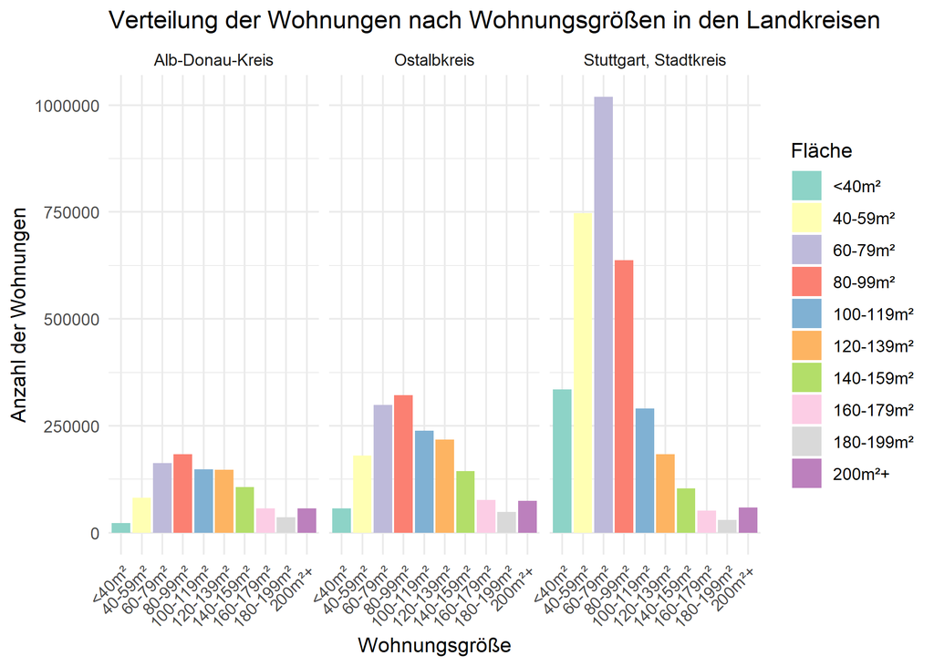

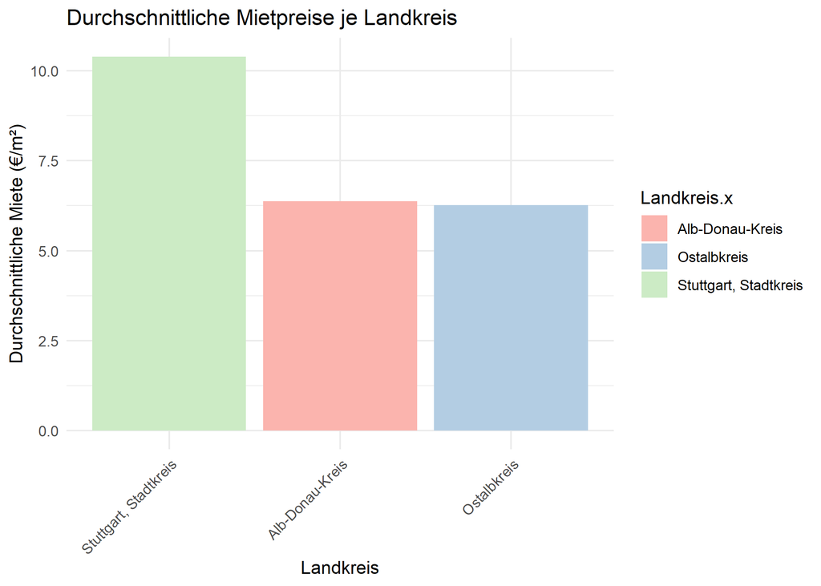

Erste Grafik

Diese Grafik zeigt die Verteilung der Wohnungsgrößen nach Wohnfläche für die drei Landkreise: Stuttgart, Alb-Donau-Kreis und Ostalbkreis. Die x-Achse repräsentiert die verschiedenen Kategorien der Wohnungsgrößen, während die y-Achse die Anzahl der Wohnungen in jeder Kategorie zeigt. Jede Farbe in den Balken steht für eine bestimmte Wohnungsgröße, die in der Legende angezeigt wird.

In Stuttgart gibt es eine verhältnismäßig höhere Anzahl an Wohnungen mit kleineren Wohnflächen (<80m²) im Vergleich zu den ländlichen Landkreisen. Dies ist typisch für städtische Gebiete, wo Platz begrenzt und Wohnraum teurer ist. Der Alb-Donau-Kreis und der Ostalbkreis zeigen eine ausgeglichenere Verteilung zwischen mittelgroßen und größeren Wohnungen. Dies spiegelt die typischen ländlichen Wohnverhältnisse wider, wo Familien in größeren Einheiten leben können. Größere Wohnungen (>140m²) sind in den ländlichen Landkreisen häufiger als in Stuttgart, was an der größeren Verfügbarkeit von Platz und günstigerem Bauland liegen kann.

Zweite Grafik

Diese Grafik visualisiert den durchschnittlichen Mietpreis pro Quadratmeter für die Landkreise Stuttgart, Alb-Donau-Kreis und Ostalbkreis. Die Höhe der Balken repräsentiert den durchschnittlichen Mietpreis.

Die Mietpreise in Stuttgart sind deutlich höher als in den beiden ländlichen Landkreisen, was den allgemeinen Trend widerspiegelt, dass städtische Gebiete teurer sind als ländliche. Der Vergleich der Mietpreise könnte durch Faktoren wie Nachfrage nach städtischem Wohnen, höhere Lebenshaltungskosten in der Stadt und die Verfügbarkeit von Arbeitsplätzen und Infrastruktur beeinflusst werden.

Es macht Sinn, den Alb-Donau-Kreis und den Ostalbkreis als eigene Regionen zu betrachten, um regionale Besonderheiten wie die Verteilung der Wohnungsgrößen und Mietpreise zu identifizieren. Innerhalb der ländlichen Landkreise gibt es möglicherweise große Unterschiede zwischen individuellen Gemeinden und Ortschaften, die durch Betrachtung auf Kreisebene verdeckt werden könnten.

Vergleich Stadt vs. Land: Der direkte Vergleich von Stadt- (Stuttgart) und Landkreisen (Alb-Donau-Kreis und Ostalbkreis) macht Sinn, um die typischen Unterschiede in Wohnungsgrößenverteilung und Mietpreisentwicklung zu beleuchten. Allerdings sollte dabei beachtet werden, dass verschiedene kulturelle, wirtschaftliche und infrastrukturelle Faktoren in Stadt- und Landregionen die Wohnsituation beeinflussen. Beispielsweise können städtische Gebiete aufgrund der Nähe zu Arbeitsplätzen, Schulen und städtischen Dienstleistungen höhere Mietpreise und kleinere Wohnungseinheiten aufweisen.

# Zusatzfrage (optional)

Diese Frage ist von der Bearbeitung her etwas schwieriger. Bevor Sie sich an diese Aufgabe machen, sollten Sie sicherstellen, dass Sie alle vorherigen Fragen ausführlich beantwortet haben. Eine korrekte Beantwortung dieser Frage gibt einen Punktebonus von 3 Punkten (das Projekt umfasst insgesamt 30 Punkte, inkl. Screencast).

Nachdem Sie sich in den bisherigen Aufgaben ausführlich mit den allgemeinen Einflussfaktoren auf die Mietpreise befasst haben, rückt nun ein spezifischer Aspekt in den Fokus: die Rolle der Heizungen. Insbesondere werden Sie untersuchen, wie unterschiedliche Heizungsarten und -systeme die Mietpreise beeinflussen können. Diese Betrachtung ermöglicht es ihnen, die bisherigen Analysen zu verfeinern und den Zusammenhang zwischen energetischen Standards und der Entwicklung von Mietkosten genauer zu erfassen. Aufgabe 18 führt Sie somit zu einem weiteren zentralen Detail der Mietpreisentwicklung, das insbesondere vor dem Hintergrund steigender Energiepreise und der Relevanz nachhaltiger Wohnformen an Bedeutung gewinnt.

18. Lesen Sie den Datensatz `Heiztypen_Zensus.csv` ein und speichern diesen als `heiztypen` ab. Neben den Ihnen bekannten Variablen, finden Sie dort 6 weitere Variablen, die Auskunft über die Heizarten der jeweiligen Wohnung geben. Diese werden wie folgt beschrieben:
- HEIZTYP__1: Gebäude mit Heizungsart Fernheizung (Fernwärme) (Anzahl)
- HEIZTYP__2: Gebäude mit Heizungsart Etagenheizung (Anzahl)
- HEIZTYP__3: Gebäude mit Heizungsart Blockheizung (Anzahl)
- HEIZTYP__4: Gebäude mit Heizungsart Zentralheizung (Anzahl)
- HEIZTYP__5: Gebäude mit Heizungsart Einzel- oder Mehrraumöfen (auch Nachtspeicherheizung) (Anzahl)
- HEIZTYP__6: Gebäude mit Heizungsart Keine Heizung im Gebäude oder in den Wohnungen (Anzahl)

Erstellen Sie eine neue Spalte `heiztypen_gesamt`, welche die Summe über alle Heiztypen hinweg bildet. Bestimmen Sie weiterhin den Anteil der jeweiligen Heiztypen je Gemeinde (als Anteil aller Heizarten). Nun sollen Sie eine oder mehrere passende Grafik(en) erzeugen, die je nach durchschnittlicher Größe der Wohnungen die Anteile der verschiedenen Heizungsarten abbilden. Erstellen Sie weiterhin eine oder mehrere passende Grafik(en) die den Zusammenhang zwischen den Heizungsarten und den durschnittlichen Mietpreisen darstellt. Wiederum soll der Anteil der verschiedenen Heizungsarten abhängig der Mietpreise abgebildet werden.

Beschreiben und interpretieren Sie ihre Schaubilder und gehen Sie insbesondere auf folgende Frage ein:

- Gibt es einen Zusammenhang zwischen der Heizungsart und der Größe der Wohnungen?
- Gibt es einen Zusammenhang zwischen der Heizungsart und den Mietpreisen?
- Was könnten Gründe sein, warum in bestimmten Wohnungsgrößen eher bestimmte Heizungstypen eingebaut werden und andere nicht?
- Warum könnte es sein, dass bei manchen Heizungsarten die Mietpreise höher sind als bei anderen?
- Was könnte die Bundesregierung machen, um trotz neuer und moderner Heizungssysteme die Mietpreise nach oben hin zu beschränken?

*Hinweis 1:* Überlegen Sie sich, ob es ihrer Ansicht nach Sinn macht, die jeweiligen Wohnungsgrößen und durchschnittlichen Mietpreise in Segmente zu unterteilen.

*Hinweis 2:* Eine Möglichkeit die Beziehung zwischen Heizungsarten und Wohnungsgrößen bzw. Heizungsarten und Mietpreisen zu visualisieren wäre beispielsweise ein “stacked” oder “grouped” Balkendiagramm. Überlegen Sie sich, warum diese Form der Darstellung besonders gut geeignet wäre.

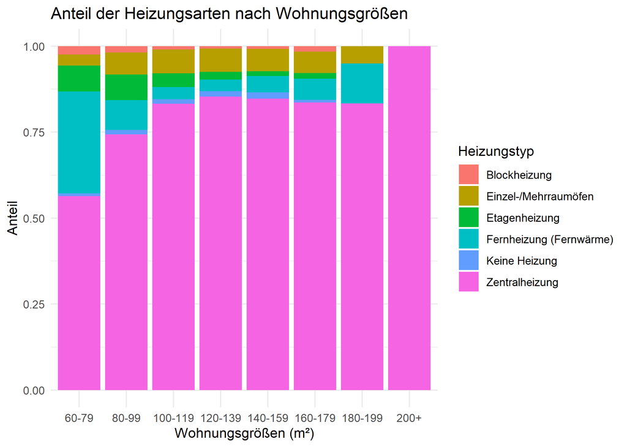

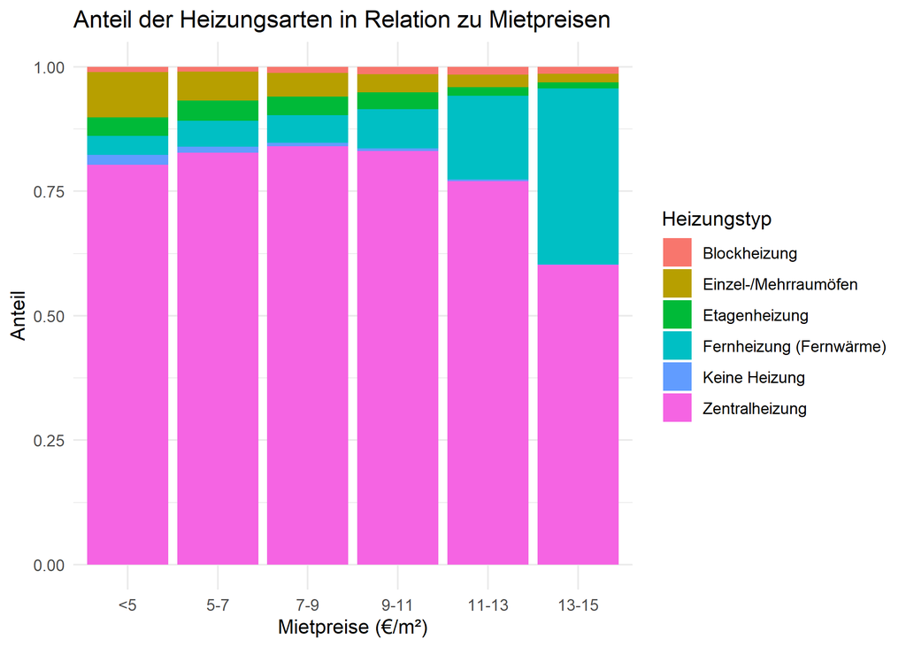

Grafik 1

Das Diagramm, das die Verteilung der Heizungsarten nach Wohnungsgrößen zeigt, verwendet ein gestapeltes Balkendiagramm. Auf der x-Achse sind die Wohnungsgrößensegmente eingetragen , während die y-Achse den Anteil der verschiedenen Heizungsarten anzeigt. Jede Heizungsart ist durch unterschiedliche Farben repräsentiert. Aus dem Diagramm ist zu erkennen das die mit abstand häufigste Art des heizens eine Zentralheizung ist. Dieses Heizsystem ist effizient, um große Flächen zu beheizen.

Grafik 2 Das zweite Diagramm zeigt die Verteilung der Heizungsarten in Abhängigkeit von Mietpreissegmenten (z.B. “<5”, “5-7”, etc.). Auch hier wird ein gestapeltes Balkendiagramm genutzt, um die Anteile der verschiedenen Heizungsarten innerhalb jedes Mietpreissegments darzustellen. Es kann beobachtet werden, dass Wohnungen mit moderneren Heizsystemen wie Fernwärme tendenziell höhere Mietpreise haben. Dies könnte darauf zurückzuführen sein, dass diese Systeme nicht nur effizientere Beheizung bieten, sondern auch einen höheren Wohnkomfort bieten, was sich auf die Mietpreise auswirken kann. Die günstigeren Mietpreissegmente könnten hingegen eher mit einfacheren oder älteren Heizsystemen wie Einzel- oder Mehrraumöfen ausgestattet sein. Jedoch ist auch hier der größteteil der Wohnungen mit einer Zentralheizung ausgestattet.

Warum könnte es sein, dass bei manchen Heizungsarten die Mietpreise höher sind als bei anderen?

Die höheren Mietpreise bei bestimmten Heizungsarten können auf folgende Gründe zurückzuführen sein: Energieeffizienz: System mit höherer Effizienz wie Fernwärme oder moderne Zentralheizungen können langfristige Einsparungen bei Energiekosten bedeuten, was sich in einer höheren Anfangsmiete niederschlägt. Komfort und Verlässlichkeit: Moderne Heizsysteme bieten oft mehr Komfort und Verlässlichkeit, was Mietpreisaufschläge rechtfertigen kann.

Was könnte die Bundesregierung machen, um trotz neuer und moderner Heizungssysteme die Mietpreise nach oben hin zu beschränken?

Um die Mietpreise trotz neuer Heizungssysteme zu begrenzen, könnte die Bundesregierung verschiedene Maßnahmen in Erwägung ziehen: Subventionen: Unterstützung für die Nachrüstung von energieeffizienten Heizsystemen ohne auf die Mieten umzulegen. Maximalmietenregelungen: Einführung von Vorschriften, die verhindern, dass Modernisierungskosten vollständig auf Mieter abgewälzt werden. Anreize für ökologisches Bauen: Finanzielle Anreize für Bauherren und Eigentümer, um umweltfreundliche, aber kostengünstige Heizlösungen zu implementieren. Bildung und Förderung: Aufklärung über die Vorteile energieeffizienter Systeme und Unterstützung für Technologien, die hohe Investitionskosten mit sich bringen könnten.

Solche Strategien könnten helfen, einen Anstieg der Mieten zu verhindern, obwohl moderne Heizsysteme installiert werden.

Durch verwendung eines stacked Diagramms kann man auf einen Blick sofort erkennen das die meisten Wohnungen Zentralheizungen benutzten. Allgemein ist ein solches gut um eine Verteilung auf einen Blick gut zu erkennen.

Wie Sie in der Aufgabe 15 gesehen haben, haben Ulm und Stuttgart, sowie Dresden und Chemnitz ähnliche Verhältnisse bezüglich der Verteilung der Mietkosten über die Stadt hinweg. Aufgrund dessen beschränken Sie sich bei dieser Aufgabe auf die Städte Stuttgart und Dresden. Hier sollen Sie sich die einzelnen Heizungsarten über die Stadtteile hinweg anschauen, wie sich diese verteilen und ob hier Ähnlichkeiten zur Mietpreissstrukur vorliegt. Weiterhin sind vor allem die Heizungsarten Fernwärme, Zentralheizung und Etagenheizung in viele deutschen Wohnungen größtenteils verbaut, weshalb Sie gerade deswegen diese drei Heiztypen genauer beleuchten und untersuchen sollen.

19. Deshalb sollten Sie sich in einem ersten Schritt [diese Geogitter-Daten für die verschiedenen Heinzungsarten vom statistischen Bundesamt herunterladen](https://www.zensus2022.de/static/Zensus_Veroeffentlichung/Zensus2022_Heizungsart.zip). Speichern Sie die zip-Datei im Ordner `Daten` ab. Nutzen Sie erneut den Datensatz shape_file aus der Aufgabe 4 und joinen Sie die Informationen zu den Heizungsarten über die Variablen `x_mp_1km` und `y_mp_1km`.

In ihrem Datensatz können Sie sehen, dass es Einträge mit “-” gibt. Diese sollen sie für alle Heizungstypen durch 0 ersetzen. Achten Sie auch darauf, dass über alle Heizungstypen hinweg die Werte als numeric vorliegen.

Erstellen Sie nun für die Heizungsarten “Fernheizung”, “Etagenheizung” und “Zentralheizung” eine neue Spalte mit dem Anteil des jeweiligen Heizungstyps an allen Heizungen (`Insgesamt_Heizungsart`) je Gemeinde. Schließlich sollen Sie nun für die drei genannten Heizungsarten eine Karte erzeugen, welche den Anteil je Gitterebene im Stadtbezirk darstellt.

Beschreiben und interpretieren Sie ihre Grafiken. Berücksichtigen Sie dabei insbesondere folgende Fragen:

- Wo liegen Besonderheiten oder Muster in beiden Städten?
- Gibt es in Stuttgart und Dresden Stadtteile, bei denen bestimmte Heizungstypen in Einklang mit den Mietpreisen stehen, genauer gesagt, welche Heizungsarten korrelieren mit höheren oder niedrigeren Mietpreisen? Vergleichen Sie dazu die Ergebnisse aus Aufgabe 15.
- Was könnten Gründe sein, dass in bestimmten Stadtteilen vorwiegend eine bestimmte Form der Heizung eingebaut ist?
- Gibt es Unterschiede zwischen Ost- und Westdeutschland?
- Haben die Städte Stuttgart oder Dresden in den letzen Jahren Modernisierungen angestoßen oder Neuerungen umgesetzt und finanziell unterstützt, sodass es dort zu größeren Anpassungen bei der Heizungstechnik kam?

*Hinweis 1:* Sie sollen insgesamt für jede Stadt (Stuttgart und Dresden) drei verschiedene Karten erzeugen.

*Hinweis 2:* Achten Sie auf eine sinnvolle Einteilung und Darstellung in den Karten. Nutzen Sie die Karten aus vorherigen Aufgaben als Hilfestellung.

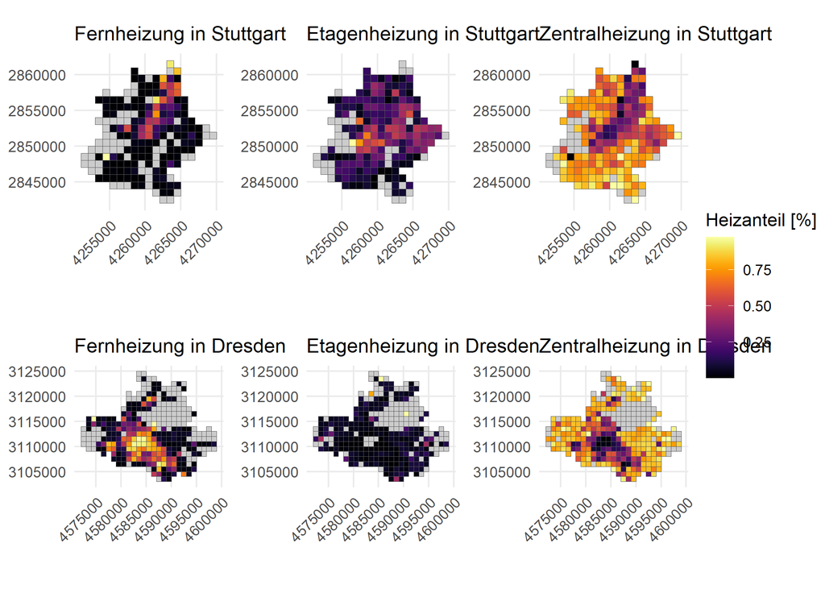

- Wo liegen Besonderheiten oder Muster in beiden Städten?

- Gibt es in Stuttgart und Dresden Stadtteile, bei denen bestimmte Heizungstypen in Einklang mit den Mietpreisen stehen, genauer gesagt, welche Heizungsarten korrelieren mit höheren oder niedrigeren Mietpreisen? Vergleichen Sie dazu die Ergebnisse aus Aufgabe 15.

In Stadtteilen mit meist neueren oder modernisierten Gebäuden sind moderner ausgestattete Heizungen (meist Zentralheizung oder Fernwärme) vorherrschend. Diese korrelieren oft mit höheren Mietpreisen. In älteren Stadtteilen, wo oft Etagenheizungen verwendet werden, ist die Mietpreisenstruktur oft niedriger und fällt möglicherweise mit Bestandsmieten zusammen.

- Was könnten Gründe sein, dass in bestimmten Stadtteilen vorwiegend eine bestimmte Form der Heizung eingebaut ist?

Baualter: Ältere Gebäude, die nicht renoviert wurden, neigen dazu, alternative oder individuellere Heizsysteme zu haben (wie Einzelöfen). Städtische Entwicklung: Gebiete, die signsifikante städtische Investitionen erhalten haben, zeigen nicht nur moderne Heizlösungen, sondern auch dazugehörige Mietpreissteigerungen. Infrastrukturnähe: Nähe zu Fernwärmequellen oder Stadtkernen kann die Wahl der Heizungsart variieren.

- Gibt es Unterschiede zwischen Ost- und Westdeutschland?

Plattenbau und Fernwärme: In Dresden (Ostdeutschland) können größere Bestände an Plattenbauten mit zentralisierter Fernwärme vorhanden sein. Urbanisierungsgrad: Unterschiede im Urbanisierungsgrad und bauliche Standards zwischen Ost- und Westdeutschland können unterschiedliche Präferenzen oder Notwendigkeiten bei Heizungsarten erlären.

- Haben die Städte Stuttgart oder Dresden in den letzen Jahren Modernisierungen angestoßen oder Neuerungen umgesetzt und finanziell unterstützt, sodass es dort zu größeren Anpassungen bei der Heizungstechnik kam?

Stuttgart: Bekannt für seine wirtschaftliche Stärke könnte es in letzter Zeit in die Renovierung städtischer Infrastruktur investiert haben, wozu auch Heizsysteme gehören, die zu einer wachsenden Präsenz moderner Heizsysteme führen.

Dresden: In Dresden, wie in vielen Städten in den neuen Bundesländern, gab es umfangreiche Sanierungen im Rahmen der ‘Aufbau Ost’-Initiativen, die vermutlich zu einer stärkeren Einführung effizienterer Heizungsarten geführt haben.

Durch die neueren Bemühungen, Gebäude energieeffizienter zu machen, könnten Regierungen und Städte finanzielle Unterstützung zur Modernisierung von Heizsystemen angeboten haben, was in der Verteilung neuer Heizungsarten reflektiert wird.

Abschließend sollen Sie die Zusatzaufgabe noch einmal rekapitulieren und einige Fragen dazu beantworten.

20. Sie sollen sich noch einmal bewusst werden, was Sie in den vorherigen Aufgaben analysiert haben und in welcher Form ihre Ergebnisse anwendbar und verallgemeinbar sind. Beantworten Sie dazu Frage 1 und 2.

Frage 1: Betrachten Sie hierzu noch einmal exemplarisch die Städte Stuttgart und Dresden.

- Sind die Zusammenhänge zwischen Mietpreisen in den Städten und sozioökonomischer Faktoren vor allem auf Unterschiede zwischen den Städten oder auf Unterschiede innerhalb der Stadt zurückzuführen. Bei welchen Faktoren ist dies der Fall, wo nicht?
- Wie kann der Staat im Hinblick auf die unterschiedlichen Heizungsarten in den Städten eingreifen, um Wohnraum preiswerter zu gestalten?

Frage 2: Schauen Sie sich noch einmal die Verteilung der Heizungsarten (Fern-, Etagen- und Zentralheizungen) für Stuttgart und Dresden in Aufgabe 19 an. Betrachten Sie im Vergleich dazu ihre Grafik aus Aufgabe 8, sowie ihre Tabelle in Aufgabe 13?

- Was fällt Ihnen hier auf?
- Gibt es bestimmte Heizungstypen, die nur in alten oder neuen Wohnungen vorkommen?
- Welche Schlüsse würden Sie ziehen, die mit Handlungen der Politik einhergehen?

Frage 1:

Unterschiede innerhalb der Städte: In Stuttgart sind die Mietpreise stark zentralisiert und besonders in der Innenstadt hoch. Dies führt zu einer sozioökonomischen Segregation, bei der wohlhabendere Menschen in den zentralen Stadtteilen leben, während Menschen mit geringerem Einkommen eher in die peripheren Gebiete ausweichen müssen. Dresden zeigt eine weniger ausgeprägte Differenzierung, wobei die Unterschiede zwischen Innenstadt und Randbezirken nicht so extrem sind. Dies kann auf eine gleichmäßigere wirtschaftliche Entwicklung und eine stärkere soziale Durchmischung hinweisen.

Unterschiede zwischen den Städten: Die wirtschaftliche Stärke und die hohe Konzentration von Unternehmen und Industrien in Stuttgart führen zu generell höheren Mietpreisen im Vergleich zu Dresden. In Dresden sind trotz gesunkener Unterschiede zwischen zentralen und peripheren Zonen die Mietpreise insgesamt niedriger.

Faktoren, die stark beeinflussen: Infrastruktur und Arbeitsmarktdynamik in Stuttgart mit Einfluss auf die steigenden Mieten im Zentrum. Städtebau und historische Entwicklungsphasen: Stuttgart hat mehr Investitionen und Modernisierungen erlebt, was sich in den Mietpreisen widerspiegelt.

Staatliche Eingriffe zur Preisgestaltung bei Wohnraum: Förderung von kostengünstigen, modernen Heizsystemen durch Subventionen und finanzielle Anreize für Gebäudebesitzer, energetisch effizienter zu modernisieren. Unterstützung bei der Bereitstellung von Sozialwohnungen und gezielte Bautätigkeiten in städtischen Randgebieten. Programme zur Förderung und Infrastrukturentwicklung in benachteiligten Stadtvierteln, um ungleich verteilte Lebenschancen auszugleichen.

Frage 2:

Heizungstypen in alten oder neuen Wohnungen: Fernheizsysteme und moderne Zentralheizungen sind meist in neueren oder modernisierten Gebäuden zu finden, die den Wärmestandard heben. Ältere, nicht umfassend modernisierte Wohnungen tendieren zu Etagenheizungen oder individuellen Ofenlösungen, die mit niedrigeren Kosten assoziiert sind.

Schlussfolgerungen, die sich auf politische Schritte beziehen: Politische Anreize für die Modernisierung von Heizsystemen könnten den Energieverbrauch senken und die Wohnqualität erhöhen. Gerade in Dresden, das eine umfassende Sanierung erfahren hat, zeigt sich der Nutzen von politisch gesteuerten Modernisierungsmaßnahmen als effektive Möglichkeit, Energieeffizienz zu fördern. In Stuttgart könnte bestehender Wohnraum durch steuerliche oder finanzielle Anreize zur Modernisierung und energetischen Sanierung unterstützt werden, um einheitliche Lebensqualitätsstandards zu fördern und die Mietpreissteigerung besser zu regulieren.

Diese Beobachtungen und Strategien unterstreichen die Bedeutung der Infrastrukturentwicklung und Modernisierungsprogramme im städtischen Bereich, um sozialökonomische Unterschiede zu minimieren und eine durchgängige Wohnraumversorgung auf einem bestimmten Standard gewährleisten zu können.